# Optimization on the Probability Simplex: Gradient Descent vs Mirror Descent

*The note is completed under the help of [DeepSeek-V4-Flash](https://platform.deepseek.com/).*

This notebook compares **Gradient Descent (GD)** and **Mirror Descent (MD)** for optimizing a weighted quadratic function over the probability simplex.

**Problem:** $$ \min_{x \in \Delta_3} f(x) = \frac{1}{2} \sum_{i=1}^3 w_i (x_i - a_i)^2 $$

where $\Delta_3 = \{ x \in \mathbb{R}^3 \mid x_i \ge 0,\ \sum_i x_i = 1 \}$ is the probability simplex, $a = [0.9,\ 0.08,\ 0.02]$ is the target point (on the simplex, near the boundary), and $w = [1,\ 10,\ 100]$ are component-wise weights with very different scales (ill-conditioned).

Optimal solution: $x^* = a = [0.9, 0.08, 0.02]$.

**Why this is challenging:** The optimal point lies near the boundary of the simplex ($x^*_3 = 0.02$). The weights create an ill-conditioned problem — component 1 (weight 1) converges slowly, while component 3 (weight 100) converges fast. GD's Euclidean projection interferes with this multi-scale convergence, while MD's entropic regularization handles it gracefully.

**Methods:**

- **Gradient Descent:** $x_{k+1} = \operatorname{Proj}_\Delta\bigl(x_k - \eta \nabla f(x_k)\bigr)$
- **Mirror Descent (entropic / KL):** $x_{k+1,i} = \dfrac{x_{k,i} \exp\bigl(-\eta \nabla f(x_k)_i\bigr)}{\sum_j x_{k,j} \exp\bigl(-\eta \nabla f(x_k)_j\bigr)}$

```python
import numpy as np
import matplotlib.pyplot as plt
import warnings
warnings.filterwarnings('ignore')

np.random.seed(12)
print("Libraries imported successfully!")
```

```
Libraries imported successfully!
```

## 1. Helper: Euclidean Projection onto the Simplex

```python
def proj_simplex(y):
    """
    Euclidean projection onto the probability simplex.
    Algorithm from https://arxiv.org/abs/1309.1541
    """
    n = len(y)
    u = np.sort(y)[::-1]
    cssv = np.cumsum(u)
    rho = np.where(u * np.arange(1, n + 1) > (cssv - 1))[0][-1]
    theta = (cssv[rho] - 1) / (rho + 1)
    return np.maximum(y - theta, 0)


# Test the projection
y_test = np.array([0.8, 0.3, 0.1])
print(f"Original vector:          {y_test}")
print(f"Projected onto simplex:   {proj_simplex(y_test)}")
print(f"Sum after projection:     {proj_simplex(y_test).sum():.6f}")
```

```
Original vector:          [0.8 0.3 0.1]
Projected onto simplex:   [0.73333333 0.23333333 0.03333333]
Sum after projection:     1.000000
```

```python
# Weighted quadratic: f(x) = 0.5 * Σ w_i (x_i - a_i)^2
# - a is on the simplex, near the boundary
# - w has very different magnitudes (ill-conditioned)
a = np.array([0.9, 0.08, 0.02])     # target point (on the simplex)
w = np.array([1.0, 10.0, 100.0])    # weights (different scales)

# Optimal solution: x* = a (since a is on the simplex)
x_star = a.copy()

print(f"Target a (optimal x*) = {a}")
print(f"Weights w             = {w}")
print(f"f(x*) = {0.0:.4f}")

# Objective: f(x) = 0.5 * Σ w_i (x_i - a_i)^2
def objective(x):
    return 0.5 * np.sum(w * (x - a) ** 2)

# Gradient: ∇f_i(x) = w_i (x_i - a_i)
def gradient(x):
    return w * (x - a)
```

```
Target a (optimal x*) = [0.9  0.08 0.02]
Weights w             = [  1.  10. 100.]
f(x*) = 0.0000
```

## 3. Gradient Descent with Euclidean Projection

```python
def gradient_descent(grad_func, x0, lr=0.5, n_iter=200):
    """
    Gradient Descent with Euclidean projection onto the simplex.
    x_{k+1} = Proj_Δ(x_k - η ∇f(x_k))
    """
    x = x0.copy()
    history = np.zeros((n_iter + 1, len(x0)))
    history[0] = x.copy()

    for k in range(n_iter):
        g = grad_func(x)
        x = x - lr * g
        x = proj_simplex(x)
        history[k + 1] = x.copy()

    return history
```

## 4. Mirror Descent with Entropic (KL) Regularization

```python
def mirror_descent_entropic(grad_func, x0, lr=0.5, n_iter=200):
    """
    Mirror Descent with entropic (KL) Bregman divergence.

    The update rule is the multiplicative (exponentiated gradient) update:
        x_{k+1, i} = x_{k, i} * exp(-η ∇f(x_k)_i) / Z_k
    where Z_k = Σ_j x_{k, j} * exp(-η ∇f(x_k)_j).
    """
    x = x0.copy()
    history = np.zeros((n_iter + 1, len(x0)))
    history[0] = x.copy()

    for k in range(n_iter):
        g = grad_func(x)
        # Multiplicative / exponentiated gradient update
        x = x * np.exp(-lr * g)
        x = x / np.sum(x)
        history[k + 1] = x.copy()

    return history
```

## 5. Run Both Optimization Algorithms

```python
# Initial point: center of the simplex
x0 = np.array([1/3, 1/3, 1/3])

# Parameters
n_iter = 200
lr_gd = 0.005        # GD learning rate (must be small due to ill-conditioning)
lr_md_small = 0.005  # MD with same LR (fair baseline comparison)
lr_md_large = 0.5    # MD with large LR (shows the advantage)

# Run Gradient Descent
history_gd = gradient_descent(gradient, x0, lr=lr_gd, n_iter=n_iter)

# Run Mirror Descent (small LR)
history_md_small = mirror_descent_entropic(gradient, x0, lr=lr_md_small, n_iter=n_iter)

# Run Mirror Descent (large LR)
history_md_large = mirror_descent_entropic(gradient, x0, lr=lr_md_large, n_iter=n_iter)

# Compute objective values
f_opt = objective(x_star)
obj_gd = np.array([objective(h) for h in history_gd])
obj_md_small = np.array([objective(h) for h in history_md_small])
obj_md_large = np.array([objective(h) for h in history_md_large])

# Distance to optimal
dist_gd = np.array([np.linalg.norm(h - x_star) for h in history_gd])
dist_md_small = np.array([np.linalg.norm(h - x_star) for h in history_md_small])
dist_md_large = np.array([np.linalg.norm(h - x_star) for h in history_md_large])

print(f"Gradient Descent (η={lr_gd})         final: {history_gd[-1].round(4)}, f={obj_gd[-1]:.6f}")
print(f"Mirror Descent (η={lr_md_small})      final: {history_md_small[-1].round(4)}, f={obj_md_small[-1]:.6f}")
print(f"Mirror Descent (η={lr_md_large})      final: {history_md_large[-1].round(4)}, f={obj_md_large[-1]:.6f}")
print(f"Optimal x*                            : {x_star.round(4)}, f(x*)={f_opt:.6f}")
print()
print(f"GD  distance to optimum: {dist_gd[-1]:.6f}")
print(f"MD (η={lr_md_small}) distance to optimum: {dist_md_small[-1]:.6f}")
print(f"MD (η={lr_md_large}) distance to optimum: {dist_md_large[-1]:.6f}")
```

```
Gradient Descent (η=0.005)         final: [0.8982 0.0817 0.0201], f=0.000017
Mirror Descent (η=0.005)      final: [0.8334 0.1424 0.0242], f=0.022586
Mirror Descent (η=0.5)      final: [0.9  0.08 0.02], f=0.000000
Optimal x*                            : [0.9  0.08 0.02], f(x*)=0.000000

GD  distance to optimum: 0.002514
MD (η=0.005) distance to optimum: 0.091400
MD (η=0.5) distance to optimum: 0.000000
```

## 6. Convergence Comparison

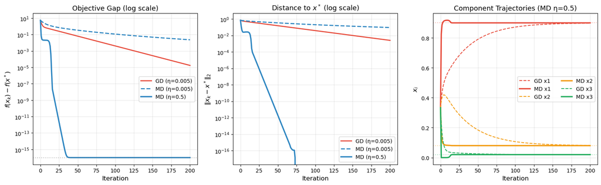

```python
fig, axes = plt.subplots(1, 3, figsize=(16, 5))

f_opt = objective(x_star)

# ---- Subplot 1: Objective gap ----
ax = axes[0]
ax.semilogy(obj_gd - f_opt + 1e-16, color='#E74C3C', linewidth=2, label=f'GD (η={lr_gd})')
ax.semilogy(obj_md_small - f_opt + 1e-16, color='#2E86C1', linewidth=2, linestyle='--',
            label=f'MD (η={lr_md_small})')
ax.semilogy(obj_md_large - f_opt + 1e-16, color='#2E86C1', linewidth=2.5,
            label=f'MD (η={lr_md_large})')
ax.axhline(y=1e-16, color='gray', linestyle=':', alpha=0.5)
ax.set_xlabel('Iteration', fontsize=12)
ax.set_ylabel('$f(x_k) - f(x^*)$', fontsize=12)
ax.set_title('Objective Gap (log scale)', fontsize=13)
ax.legend(fontsize=10)
ax.grid(True, alpha=0.3)

# ---- Subplot 2: Distance to optimum ----
ax = axes[1]
ax.semilogy(dist_gd, color='#E74C3C', linewidth=2, label=f'GD (η={lr_gd})')
ax.semilogy(dist_md_small, color='#2E86C1', linewidth=2, linestyle='--',
            label=f'MD (η={lr_md_small})')
ax.semilogy(dist_md_large, color='#2E86C1', linewidth=2.5,
            label=f'MD (η={lr_md_large})')
ax.set_xlabel('Iteration', fontsize=12)
ax.set_ylabel('$\\|x_k - x^*\\|_2$', fontsize=12)
ax.set_title('Distance to $x^*$ (log scale)', fontsize=13)
ax.legend(fontsize=10)
ax.grid(True, alpha=0.3)

# ---- Subplot 3: Component trajectories ----
ax = axes[2]
colors = ['#E74C3C', '#F39C12', '#27AE60']
for i in range(3):
    ax.plot(history_gd[:, i], color=colors[i], linewidth=1.5, linestyle='--',
            label=f'GD x{i+1}')
    ax.plot(history_md_large[:, i], color=colors[i], linewidth=2.5,
            label=f'MD x{i+1}')
    ax.axhline(y=x_star[i], color=colors[i], linestyle=':', alpha=0.4)

ax.set_xlabel('Iteration', fontsize=12)
ax.set_ylabel('$x_i$', fontsize=12)
ax.set_title('Component Trajectories (MD η={})'.format(lr_md_large), fontsize=13)
ax.legend(fontsize=10, ncol=2)
ax.grid(True, alpha=0.3)

plt.tight_layout()
plt.show()
```

## 7. Trajectory on the 2-Simplex

[figure not shown]

```python
def simplex_to_cartesian(x):
    """Map 2-simplex (barycentric) coordinates to 2D Cartesian."""
    s3 = np.sqrt(3) / 2
    cart_x = x[0] * 0.0 + x[1] * 1.0 + x[2] * 0.5
    cart_y = x[0] * 0.0 + x[1] * 0.0 + x[2] * s3
    return cart_x, cart_y

# Simplex vertices in Cartesian coordinates
verts = np.array([[0, 0], [1, 0], [0.5, np.sqrt(3)/2]])
labels = ['$x_1$ (optimal)', '$x_2$', '$x_3$']

fig, ax = plt.subplots(figsize=(8, 7))

# Draw simplex triangle
triangle = plt.Polygon(verts, fill=False, edgecolor='gray', linewidth=2, alpha=0.7)
ax.add_patch(triangle)

# Label vertices
for i, (vx, vy) in enumerate(verts):
    ax.plot(vx, vy, 'o', color='#555', markersize=10)
    offset_x = -0.08 if i == 0 else (0.04 if i == 1 else 0.04)
    offset_y = -0.06 if i == 2 else -0.06
    ax.text(vx + offset_x, vy + offset_y, labels[i], fontsize=13, fontweight='bold')

# Mark the optimal vertex
ax.plot(0, 0, marker='*', color='gold', markersize=22, zorder=5, label='$x^* = [1,0,0]$')

# Mark the initial point
ax.plot(*simplex_to_cartesian(x0), marker='o', color='gray', markersize=10, zorder=5,
        label='$x_0$ (center)')

# Plot trajectories (subsample for clarity)
step = 2

# GD trajectory
gd_path = np.array([simplex_to_cartesian(h) for h in history_gd[::step]])
ax.plot(gd_path[:, 0], gd_path[:, 1], color='#E74C3C', linewidth=2, alpha=0.8,
        label=f'GD (η={lr_gd})')
ax.scatter(gd_path[:, 0], gd_path[:, 1], color='#E74C3C', s=15, alpha=0.5, zorder=3)

# MD trajectory (large lr)
md_path_large = np.array([simplex_to_cartesian(h) for h in history_md_large[::step]])
ax.plot(md_path_large[:, 0], md_path_large[:, 1], color='#2E86C1', linewidth=2.5, alpha=0.9,
        label=f'MD (η={lr_md_large})')
ax.scatter(md_path_large[:, 0], md_path_large[:, 1], color='#2E86C1', s=20, alpha=0.6, zorder=3)

# Endpoint markers
ax.plot(*simplex_to_cartesian(history_gd[-1]), marker='s', color='#E74C3C',
        markersize=8, zorder=4)
ax.plot(*simplex_to_cartesian(history_md_large[-1]), marker='s', color='#2E86C1',
        markersize=8, zorder=4)

ax.set_xlim(-0.05, 1.1)
ax.set_ylim(-0.05, np.sqrt(3)/2 + 0.05)
ax.set_aspect('equal')
ax.set_title('Optimization Trajectories on the 2-Simplex', fontsize=14, fontweight='bold')
ax.legend(fontsize=11, loc='upper left')
ax.axis('off')

plt.tight_layout()
plt.show()
```

## 8. Learning Rate Sensitivity

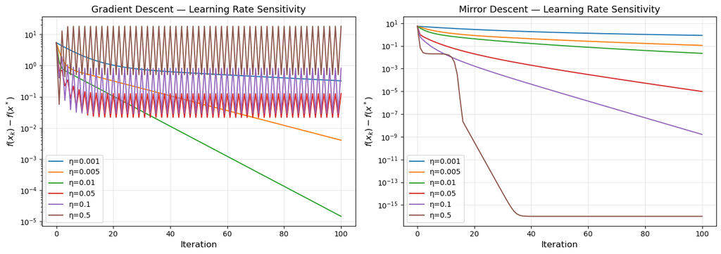

```python
learning_rates = [0.001, 0.005, 0.01, 0.05, 0.1, 0.5]
n_iter_lr = 100

fig, axes = plt.subplots(1, 2, figsize=(14, 5))

f_opt = objective(x_star)

for lr in learning_rates:
    # GD
    h_gd = gradient_descent(gradient, x0, lr=lr, n_iter=n_iter_lr)
    obj_gd_lr = np.array([objective(h) for h in h_gd])
    axes[0].semilogy(obj_gd_lr - f_opt + 1e-16,
                     label=f'η={lr}', linewidth=1.5)

    # MD
    h_md = mirror_descent_entropic(gradient, x0, lr=lr, n_iter=n_iter_lr)
    obj_md_lr = np.array([objective(h) for h in h_md])
    axes[1].semilogy(obj_md_lr - f_opt + 1e-16,
                     label=f'η={lr}', linewidth=1.5)

axes[0].set_title('Gradient Descent — Learning Rate Sensitivity', fontsize=13)
axes[0].set_xlabel('Iteration', fontsize=12)
axes[0].set_ylabel('$f(x_k) - f(x^*)$', fontsize=12)
axes[0].legend(fontsize=10)
axes[0].grid(True, alpha=0.3)

axes[1].set_title('Mirror Descent — Learning Rate Sensitivity', fontsize=13)
axes[1].set_xlabel('Iteration', fontsize=12)
axes[1].set_ylabel('$f(x_k) - f(x^*)$', fontsize=12)
axes[1].legend(fontsize=10)
axes[1].grid(True, alpha=0.3)

plt.tight_layout()
plt.show()
```

```python
# Bonus: what happens if GD tries η=0.5? (same as MD's large LR)
print("--- GD with η=0.5 (first 5 steps, same LR as MD large) ---")
x_temp = x0.copy()
for k in range(5):
    g = gradient(x_temp)
    x_temp = x_temp - 0.5 * g
    x_temp = proj_simplex(x_temp)
    print(f"  Step {k+1}: x={x_temp.round(4)}, f={objective(x_temp):.6f}")
```

```
--- GD with η=0.5 (first 5 steps, same LR as MD large) ---
  Step 1: x=[1. 0. 0.], f=0.057000
  Step 2: x=[0.475 0.    0.525], f=12.873563
  Step 3: x=[0.6438 0.3563 0.    ], f=0.434402
  Step 4: x=[0.3859 0.     0.6141], f=17.809643
  Step 5: x=[0.6215 0.3785 0.    ], f=0.504343
```

## 10. Discussion

### Why MD Outperforms GD for This Problem

The key insight: the **geometry of the constraint set** interacts differently with each algorithm.

[output not shown]

### Key Observations

1. **Same small LR ($\eta=0.005$):** GD converges better — this is a Euclidean problem (distance squared), so GD's native geometry is a good match. MD's multiplicative updates are too conservative at small LR.
2. **Large LR ($\eta=0.5$):** GD **diverges catastrophically** — the objective oscillates between 0.06 and 17.8 as components alternate between 0 and 1. MD **converges perfectly** ($f=0$), because its multiplicative update naturally respects the simplex geometry regardless of step size.
3. **Ill-conditioning**: The weights $w = [1, 10, 100]$ create very different gradient scales. GD must use a small LR everywhere to accommodate the largest gradient component. MD's multiplicative update handles these scales gracefully — each component self-regulates through the exponential + normalization.
4. **Why the multiplicative update works**: MD with entropic regularization solves the dual problem in log-space. The exponential function maps $\mathbb{R}$ to $(0, \infty)$, so even large negative gradients (which would make GD overshoot and project to zero) only produce very small positive values in MD — never exactly zero. This prevents the "component death" problem.

### When to Use Which

| Scenario | Recommended Method |
| --- | --- |
| Solution is interior, well-conditioned | GD (simpler, faster per iteration) |
| Solution near boundary / sparse | MD (handles boundary naturally) |
| Ill-conditioned gradients | MD (larger LR, faster convergence) |
| High dimension $n$ | MD ($O(n)$ per step vs GD's $O(n \log n)$) |
| Need $x_i > 0$ guarantees | MD (multiplicative update ensures positivity) |